# 静岡市オープンデータ分析

組織 企画課 ５歳階級別・町名別人口（３ヶ月毎更新） 平成２８年１２月３１日時点（５歳階級別・町別） http://dataset.city.shizuoka.jp/dataset/kikaku20151023-028

## データインポート

```r
#csvファイルの読み込み
csv_data <- read.csv("shizuoka_R.csv")
csv_data
```

| 町コード | 区 | 町名 | 総数 | X0.4歳 | X5.9歳 | X10.14歳 | X15.19歳 | X20.24歳 | X25.29歳 | ⋯ | X45.49歳 | X50.54歳 | X55.59歳 | X60.64歳 | X65.69歳 | X70.74歳 | X75.79歳 | X80.84歳 | X85歳以上 | 世帯数 |
| --- | --- | --- | --- | --- | --- | --- | --- | --- | --- | --- | --- | --- | --- | --- | --- | --- | --- | --- | --- | --- |
| 21000 | 葵区 | 追手町 | 183 | 5 | 2 | 5 | 4 | 3 | 3 | ⋯ | 8 | 8 | 12 | 14 | 24 | 14 | 18 | 19 | 7 | 111 |
| 21010 | 葵区 | 城内町 | 97 | 4 | 5 | 2 | 5 | 4 | 3 | ⋯ | 2 | 11 | 7 | 8 | 8 | 6 | 6 | 5 | 10 | 48 |
| 21020 | 葵区 | 駿府町 | 150 | 4 | 7 | 5 | 4 | 6 | 2 | ⋯ | 11 | 11 | 9 | 11 | 10 | 16 | 4 | 14 | 7 | 74 |
| 21040 | 葵区 | 西草深町 | 1247 | 37 | 47 | 46 | 50 | 58 | 33 | ⋯ | 89 | 65 | 83 | 99 | 109 | 96 | 66 | 55 | 96 | 580 |
| 21050 | 葵区 | 東草深町 | 590 | 11 | 25 | 33 | 21 | 20 | 20 | ⋯ | 64 | 33 | 38 | 36 | 45 | 40 | 45 | 36 | 41 | 263 |
| 21060 | 葵区 | 水落町 | 806 | 15 | 33 | 36 | 35 | 27 | 24 | ⋯ | 64 | 39 | 52 | 61 | 80 | 57 | 38 | 39 | 66 | 376 |
| 21070 | 葵区 | 城東町 | 1837 | 39 | 67 | 74 | 74 | 65 | 48 | ⋯ | 127 | 126 | 89 | 133 | 190 | 136 | 129 | 104 | 154 | 808 |
| 21080 | 葵区 | 緑町 | 1004 | 28 | 67 | 63 | 58 | 32 | 42 | ⋯ | 91 | 69 | 68 | 61 | 74 | 49 | 30 | 39 | 58 | 407 |
| 21090 | 葵区 | 西千代田町 | 1576 | 62 | 76 | 58 | 63 | 76 | 76 | ⋯ | 103 | 93 | 122 | 111 | 123 | 99 | 66 | 64 | 104 | 692 |
| 21201 | 葵区 | 鷹匠一丁目 | 399 | 7 | 8 | 14 | 16 | 13 | 21 | ⋯ | 43 | 30 | 25 | 25 | 39 | 27 | 21 | 19 | 27 | 215 |
| 21202 | 葵区 | 鷹匠二丁目 | 1307 | 45 | 62 | 43 | 67 | 45 | 69 | ⋯ | 109 | 95 | 86 | 76 | 97 | 71 | 60 | 54 | 65 | 673 |
| 21203 | 葵区 | 鷹匠三丁目 | 851 | 25 | 24 | 31 | 26 | 44 | 45 | ⋯ | 69 | 64 | 52 | 46 | 62 | 41 | 54 | 27 | 58 | 460 |
| 21210 | 葵区 | 東鷹匠町 | 939 | 25 | 38 | 35 | 36 | 49 | 34 | ⋯ | 65 | 65 | 95 | 61 | 71 | 52 | 49 | 40 | 82 | 455 |
| 21220 | 葵区 | 横内町 | 452 | 13 | 15 | 22 | 17 | 39 | 16 | ⋯ | 39 | 32 | 24 | 25 | 26 | 24 | 31 | 27 | 28 | 230 |
| 21230 | 葵区 | 太田町 | 277 | 8 | 6 | 12 | 16 | 17 | 9 | ⋯ | 32 | 20 | 19 | 14 | 17 | 16 | 12 | 17 | 12 | 147 |
| 21240 | 葵区 | 巴町 | 306 | 6 | 9 | 8 | 12 | 20 | 20 | ⋯ | 22 | 24 | 21 | 24 | 30 | 16 | 19 | 12 | 21 | 147 |
| 21250 | 葵区 | 瓦場町 | 672 | 34 | 40 | 23 | 26 | 34 | 26 | ⋯ | 56 | 50 | 42 | 31 | 39 | 38 | 35 | 31 | 34 | 279 |
| 21260 | 葵区 | 春日町 | 317 | 9 | 19 | 22 | 12 | 11 | 13 | ⋯ | 27 | 20 | 12 | 21 | 18 | 21 | 14 | 12 | 23 | 138 |
| 21261 | 葵区 | 春日一丁目 | 276 | 7 | 7 | 6 | 12 | 19 | 29 | ⋯ | 23 | 27 | 18 | 12 | 12 | 12 | 16 | 11 | 17 | 152 |
| 21262 | 葵区 | 春日二丁目 | 627 | 16 | 13 | 19 | 9 | 30 | 34 | ⋯ | 32 | 32 | 49 | 45 | 53 | 47 | 48 | 50 | 36 | 359 |
| 21263 | 葵区 | 春日三丁目 | 922 | 28 | 29 | 38 | 43 | 42 | 41 | ⋯ | 87 | 73 | 60 | 68 | 84 | 55 | 40 | 40 | 37 | 459 |
| 21270 | 葵区 | 音羽町 | 1232 | 47 | 49 | 41 | 51 | 59 | 62 | ⋯ | 107 | 79 | 94 | 79 | 99 | 63 | 64 | 58 | 82 | 595 |
| 21280 | 葵区 | 相生町 | 550 | 17 | 18 | 25 | 24 | 22 | 29 | ⋯ | 47 | 34 | 32 | 38 | 40 | 37 | 26 | 26 | 38 | 270 |
| 21290 | 葵区 | 横田町 | 590 | 9 | 13 | 18 | 22 | 32 | 27 | ⋯ | 31 | 29 | 40 | 41 | 71 | 46 | 39 | 28 | 47 | 292 |
| 21300 | 葵区 | 東町 | 294 | 13 | 24 | 13 | 14 | 19 | 6 | ⋯ | 35 | 20 | 10 | 15 | 13 | 17 | 9 | 7 | 2 | 130 |
| 21310 | 葵区 | 日出町 | 235 | 3 | 8 | 7 | 6 | 12 | 30 | ⋯ | 18 | 13 | 9 | 13 | 16 | 15 | 15 | 12 | 16 | 144 |
| 21320 | 葵区 | 伝馬町 | 734 | 22 | 24 | 36 | 19 | 34 | 37 | ⋯ | 70 | 47 | 43 | 43 | 76 | 43 | 40 | 26 | 24 | 378 |
| 21330 | 葵区 | 栄町 | 77 | 0 | 2 | 0 | 0 | 5 | 1 | ⋯ | 8 | 3 | 5 | 8 | 9 | 3 | 3 | 5 | 3 | 56 |
| 21340 | 葵区 | 御幸町※秘8 | 166 | 4 | 1 | 6 | 9 | 2 | 3 | ⋯ | 21 | 14 | 16 | 11 | 17 | 10 | 12 | 11 | 9 | 85 |
| 21401 | 葵区 | 呉服町一丁目 | 514 | 39 | 34 | 21 | 17 | 10 | 15 | ⋯ | 72 | 33 | 28 | 25 | 25 | 24 | 13 | 14 | 19 | 239 |
| ⋮ | ⋮ | ⋮ | ⋮ | ⋮ | ⋮ | ⋮ | ⋮ | ⋮ | ⋮ | ⋱ | ⋮ | ⋮ | ⋮ | ⋮ | ⋮ | ⋮ | ⋮ | ⋮ | ⋮ | ⋮ |
| 11406 | 清水区 | 葛沢 | 190 | 6 | 4 | 6 | 7 | 9 | 12 | ⋯ | 9 | 15 | 19 | 10 | 16 | 11 | 16 | 11 | 14 | 62 |
| 11407 | 清水区 | 土 | 44 | 0 | 3 | 1 | 0 | 0 | 0 | ⋯ | 0 | 4 | 3 | 3 | 7 | 6 | 2 | 2 | 3 | 19 |
| 11408 | 清水区 | 中河内 | 1016 | 11 | 20 | 26 | 23 | 52 | 49 | ⋯ | 73 | 76 | 97 | 104 | 97 | 78 | 78 | 53 | 65 | 492 |
| 11409 | 清水区 | 西里 | 278 | 2 | 5 | 11 | 8 | 12 | 8 | ⋯ | 22 | 24 | 10 | 20 | 36 | 23 | 23 | 17 | 21 | 106 |
| 11410 | 清水区 | 布沢 | 178 | 5 | 14 | 3 | 13 | 6 | 5 | ⋯ | 9 | 12 | 12 | 11 | 16 | 14 | 7 | 9 | 14 | 60 |
| 11411 | 清水区 | 和田島 | 294 | 6 | 3 | 5 | 25 | 10 | 4 | ⋯ | 22 | 18 | 17 | 14 | 49 | 30 | 12 | 12 | 19 | 102 |
| 31001 | 清水区 | 蒲原 | 2490 | 105 | 93 | 109 | 145 | 136 | 186 | ⋯ | 176 | 173 | 138 | 127 | 188 | 142 | 97 | 85 | 69 | 1033 |
| 31002 | 清水区 | 蒲原一丁目 | 748 | 22 | 26 | 42 | 33 | 23 | 23 | ⋯ | 39 | 49 | 34 | 62 | 96 | 53 | 39 | 31 | 31 | 287 |
| 31003 | 清水区 | 蒲原二丁目 | 447 | 8 | 8 | 11 | 15 | 15 | 13 | ⋯ | 22 | 26 | 32 | 43 | 64 | 26 | 35 | 26 | 32 | 182 |
| 31004 | 清水区 | 蒲原三丁目 | 898 | 23 | 22 | 29 | 36 | 38 | 35 | ⋯ | 60 | 62 | 50 | 62 | 89 | 72 | 77 | 48 | 61 | 344 |
| 31005 | 清水区 | 蒲原四丁目 | 1040 | 17 | 35 | 49 | 49 | 29 | 46 | ⋯ | 70 | 56 | 71 | 80 | 101 | 96 | 82 | 52 | 54 | 428 |
| 31006 | 清水区 | 蒲原小金 | 776 | 20 | 22 | 40 | 35 | 40 | 26 | ⋯ | 55 | 55 | 62 | 46 | 57 | 74 | 56 | 34 | 41 | 290 |
| 31007 | 清水区 | 蒲原中 | 1334 | 27 | 43 | 49 | 69 | 50 | 39 | ⋯ | 88 | 86 | 72 | 84 | 150 | 123 | 95 | 80 | 87 | 524 |
| 31008 | 清水区 | 蒲原堰沢 | 643 | 8 | 13 | 22 | 21 | 25 | 19 | ⋯ | 43 | 44 | 43 | 49 | 72 | 45 | 55 | 41 | 48 | 267 |
| 31009 | 清水区 | 蒲原神沢 | 866 | 19 | 12 | 27 | 40 | 33 | 34 | ⋯ | 48 | 64 | 58 | 48 | 82 | 66 | 56 | 70 | 80 | 373 |
| 31010 | 清水区 | 蒲原新田一丁目 | 549 | 25 | 15 | 20 | 29 | 31 | 25 | ⋯ | 36 | 37 | 38 | 31 | 40 | 40 | 33 | 26 | 26 | 231 |
| 31011 | 清水区 | 蒲原新田二丁目 | 581 | 14 | 22 | 26 | 23 | 13 | 17 | ⋯ | 36 | 41 | 35 | 49 | 55 | 40 | 41 | 32 | 45 | 231 |
| 31012 | 清水区 | 蒲原新栄 | 528 | 16 | 24 | 29 | 16 | 29 | 13 | ⋯ | 38 | 28 | 37 | 42 | 57 | 35 | 32 | 19 | 10 | 204 |
| 31013 | 清水区 | 蒲原東 | 727 | 28 | 30 | 28 | 45 | 24 | 20 | ⋯ | 69 | 41 | 37 | 55 | 66 | 62 | 40 | 26 | 13 | 276 |
| 41001 | 清水区 | 由比阿僧 | 879 | 24 | 30 | 44 | 60 | 42 | 45 | ⋯ | 51 | 74 | 66 | 55 | 62 | 32 | 44 | 45 | 57 | 310 |
| 41002 | 清水区 | 由比今宿 | 936 | 9 | 15 | 31 | 33 | 35 | 33 | ⋯ | 67 | 62 | 60 | 62 | 109 | 67 | 83 | 71 | 78 | 366 |
| 41003 | 清水区 | 由比入山 | 687 | 15 | 26 | 28 | 32 | 18 | 14 | ⋯ | 42 | 31 | 45 | 75 | 78 | 42 | 44 | 35 | 52 | 255 |
| 41004 | 清水区 | 由比北田 | 869 | 26 | 26 | 24 | 34 | 43 | 41 | ⋯ | 52 | 48 | 56 | 65 | 72 | 59 | 54 | 42 | 65 | 345 |
| 41005 | 清水区 | 由比寺尾 | 446 | 10 | 16 | 12 | 18 | 21 | 16 | ⋯ | 32 | 23 | 24 | 38 | 56 | 31 | 29 | 25 | 35 | 165 |
| 41006 | 清水区 | 由比西倉澤 | 144 | 3 | 0 | 2 | 5 | 5 | 9 | ⋯ | 6 | 12 | 6 | 10 | 22 | 13 | 19 | 12 | 10 | 60 |
| 41007 | 清水区 | 由比西山寺 | 170 | 5 | 5 | 6 | 5 | 9 | 8 | ⋯ | 5 | 7 | 18 | 16 | 16 | 8 | 10 | 14 | 14 | 54 |
| 41008 | 清水区 | 由比東倉澤 | 66 | 3 | 2 | 1 | 2 | 3 | 2 | ⋯ | 5 | 1 | 6 | 6 | 6 | 3 | 8 | 6 | 3 | 29 |
| 41009 | 清水区 | 由比東山寺 | 478 | 12 | 11 | 15 | 16 | 14 | 17 | ⋯ | 30 | 27 | 34 | 53 | 51 | 43 | 24 | 21 | 32 | 171 |
| 41010 | 清水区 | 由比町屋原 | 1587 | 45 | 47 | 63 | 70 | 74 | 68 | ⋯ | 101 | 96 | 118 | 103 | 162 | 119 | 101 | 72 | 85 | 586 |
| 41011 | 清水区 | 由比 | 2175 | 80 | 79 | 103 | 108 | 77 | 103 | ⋯ | 136 | 119 | 129 | 144 | 220 | 146 | 138 | 103 | 107 | 834 |

## グラフ作成

```r
#日本語の対応
par(family = "HiraKakuProN-W3")
```

```r
#グラフで用いるラベルを作成
labels=c("0-4歳","5-9歳","10-14歳","15-19歳","20-24歳","25-29歳","30-34歳","35-39歳","40-44歳","45-49歳","50-54歳","55-59歳","60-64歳","65-69歳","70-74歳","75-79歳","80-84歳","85歳以上")
```

### 円グラフ

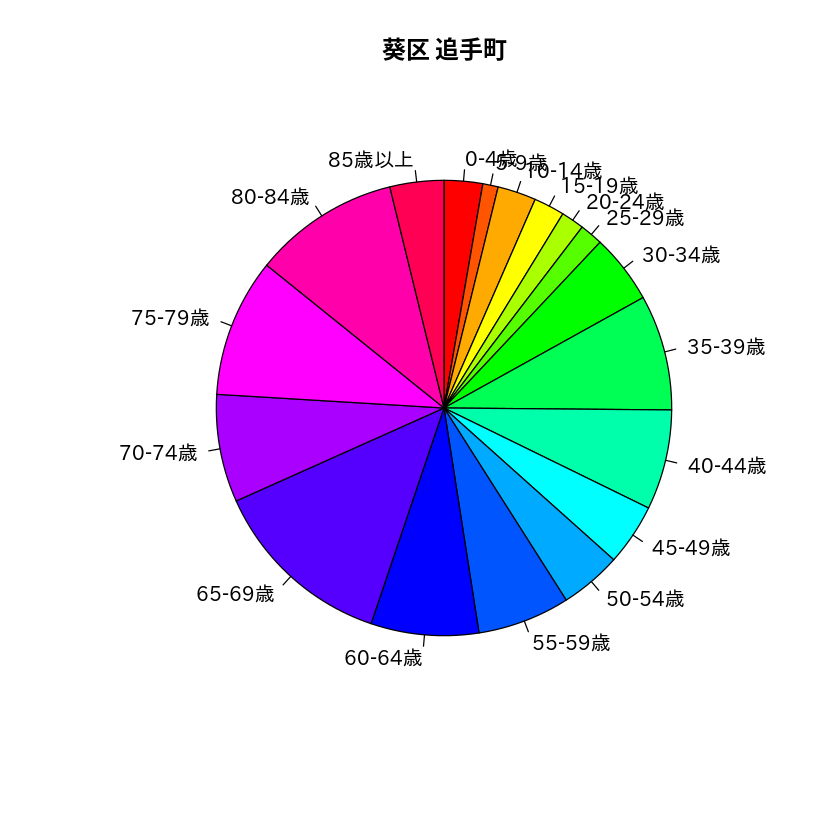

```r
index <- 1 #indexは行番号を指定
pie(as.integer(c(csv_data[index,5:22])),labels = labels,
    main = paste(csv_data[index,2],csv_data[index,3]),
    clockwise=TRUE, col = rainbow(18))
```

### 棒グラフ

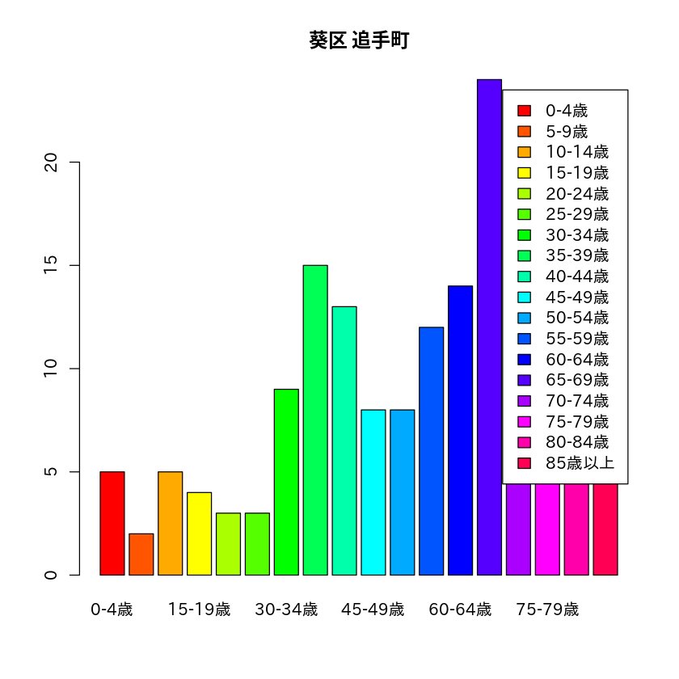

```r
barplot(as.integer(c(csv_data[index,5:22])),legend = labels,
        main = paste(csv_data[index,2],csv_data[index,3]),
        names.arg = labels, col = rainbow(18))
```

#### 積み上げグラフ

最初の10件の町別年齢層について可視化

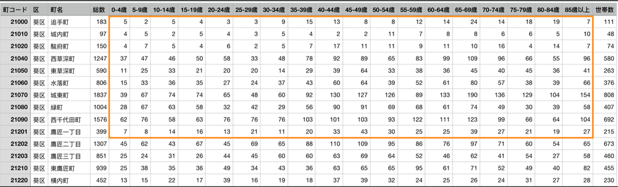

`t()`は転置する関数 : `t(csv_data[1:10,5:22])` データを取得し、転置

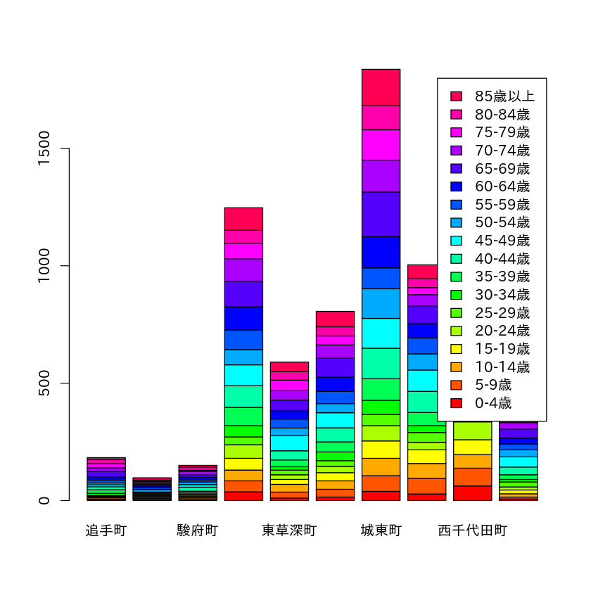

```r
barplot(t(csv_data[1:10,5:22]), legend = labels,
        col = rainbow(18), names.arg = csv_data[1:10,3])
#10件の町別年齢層
```

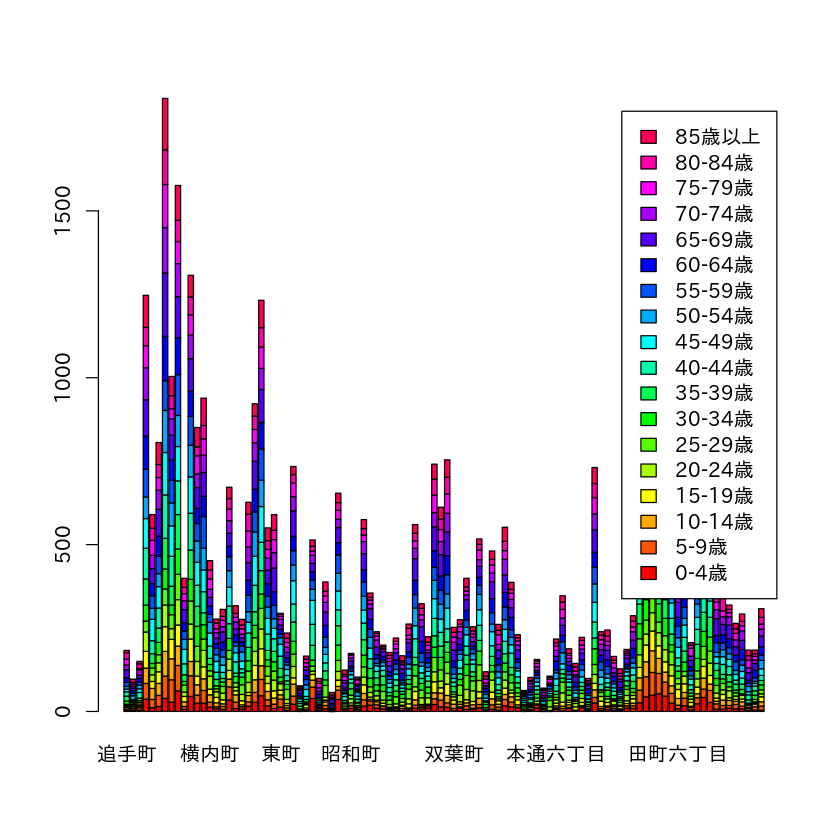

```r
#100件の町別年齢層
barplot(t(csv_data[1:100,5:22]), legend = labels,
        col = rainbow(18), names.arg = csv_data[1:100,3])
```

人口の降順に並び替えて表示をする

```r
des_data <- csv_data[csv_data$区=="葵区",] #葵区だけの町を選択
des_data <- des_data[order(des_data$総数, decreasing = TRUE),] #人口で並び替え
des_data #データを表示
```

|  | 町コード | 区 | 町名 | 総数 | X0.4歳 | X5.9歳 | X10.14歳 | X15.19歳 | X20.24歳 | X25.29歳 | ⋯ | X45.49歳 | X50.54歳 | X55.59歳 | X60.64歳 | X65.69歳 | X70.74歳 | X75.79歳 | X80.84歳 | X85歳以上 | 世帯数 |
| --- | --- | --- | --- | --- | --- | --- | --- | --- | --- | --- | --- | --- | --- | --- | --- | --- | --- | --- | --- | --- | --- |
| 330 | 27490 | 葵区 | 足久保口組 | 3444 | 110 | 193 | 220 | 162 | 95 | 106 | ⋯ | 254 | 147 | 155 | 236 | 368 | 257 | 188 | 111 | 136 | 1289 |
| 221 | 24101 | 葵区 | 瀬名一丁目 | 3281 | 111 | 131 | 134 | 177 | 175 | 160 | ⋯ | 221 | 179 | 178 | 229 | 313 | 248 | 188 | 121 | 106 | 1572 |
| 217 | 24011 | 葵区 | 瀬名川一丁目 | 2652 | 149 | 151 | 119 | 116 | 118 | 140 | ⋯ | 213 | 128 | 123 | 152 | 206 | 163 | 108 | 85 | 54 | 1147 |
| 195 | 23620 | 葵区 | 長沼 | 2625 | 183 | 150 | 107 | 95 | 94 | 115 | ⋯ | 268 | 176 | 131 | 136 | 155 | 87 | 86 | 72 | 86 | 1158 |
| 162 | 23015 | 葵区 | 北安東五丁目 | 2571 | 99 | 93 | 127 | 152 | 137 | 122 | ⋯ | 170 | 192 | 143 | 169 | 177 | 140 | 148 | 116 | 131 | 1129 |
| 223 | 24103 | 葵区 | 瀬名三丁目 | 2538 | 95 | 118 | 112 | 135 | 162 | 119 | ⋯ | 180 | 178 | 150 | 171 | 187 | 139 | 145 | 82 | 66 | 1039 |
| 135 | 22650 | 葵区 | 柳町 | 2292 | 152 | 173 | 108 | 67 | 76 | 93 | ⋯ | 174 | 134 | 95 | 120 | 140 | 101 | 101 | 82 | 111 | 939 |
| 318 | 27300 | 葵区 | 新間 | 2283 | 65 | 72 | 91 | 115 | 90 | 89 | ⋯ | 177 | 121 | 154 | 152 | 219 | 215 | 178 | 107 | 93 | 919 |
| 218 | 24012 | 葵区 | 瀬名川二丁目 | 2215 | 122 | 75 | 93 | 100 | 111 | 168 | ⋯ | 160 | 112 | 117 | 139 | 154 | 116 | 115 | 62 | 66 | 955 |
| 314 | 27246 | 葵区 | 羽鳥六丁目 | 2197 | 124 | 144 | 134 | 111 | 108 | 97 | ⋯ | 149 | 114 | 109 | 132 | 163 | 101 | 106 | 55 | 51 | 810 |
| 151 | 22862 | 葵区 | 大岩二丁目 | 2165 | 87 | 107 | 112 | 101 | 105 | 98 | ⋯ | 163 | 159 | 164 | 109 | 121 | 100 | 105 | 128 | 118 | 920 |
| 158 | 23011 | 葵区 | 北安東一丁目 | 2164 | 63 | 103 | 107 | 150 | 98 | 97 | ⋯ | 202 | 177 | 140 | 111 | 135 | 110 | 114 | 109 | 88 | 902 |
| 325 | 27430 | 葵区 | 安倍口団地 | 2163 | 24 | 42 | 60 | 78 | 61 | 47 | ⋯ | 137 | 116 | 97 | 156 | 325 | 265 | 221 | 174 | 93 | 1293 |
| 156 | 23002 | 葵区 | 安東二丁目 | 2072 | 79 | 111 | 118 | 98 | 100 | 96 | ⋯ | 182 | 147 | 134 | 127 | 151 | 96 | 94 | 81 | 84 | 850 |
| 327 | 27460 | 葵区 | 内牧 | 2025 | 53 | 79 | 74 | 75 | 70 | 69 | ⋯ | 139 | 116 | 115 | 140 | 207 | 150 | 193 | 115 | 125 | 858 |
| 222 | 24102 | 葵区 | 瀬名二丁目 | 2014 | 98 | 104 | 93 | 88 | 102 | 104 | ⋯ | 139 | 118 | 120 | 117 | 185 | 111 | 104 | 58 | 47 | 831 |
| 141 | 22690 | 葵区 | 籠上 | 1987 | 80 | 98 | 86 | 92 | 90 | 103 | ⋯ | 146 | 148 | 131 | 103 | 132 | 95 | 117 | 114 | 92 | 857 |
| 159 | 23012 | 葵区 | 北安東二丁目 | 1984 | 83 | 82 | 119 | 136 | 102 | 88 | ⋯ | 175 | 164 | 117 | 108 | 113 | 85 | 74 | 90 | 78 | 819 |
| 206 | 23802 | 葵区 | 川合二丁目 | 1970 | 78 | 79 | 90 | 93 | 89 | 94 | ⋯ | 168 | 107 | 112 | 127 | 180 | 128 | 124 | 72 | 59 | 835 |
| 265 | 24415 | 葵区 | 上伝馬 | 1967 | 103 | 73 | 89 | 90 | 106 | 119 | ⋯ | 159 | 117 | 99 | 129 | 149 | 106 | 105 | 70 | 65 | 845 |
| 201 | 23633 | 葵区 | 古庄三丁目 | 1916 | 95 | 85 | 61 | 79 | 93 | 132 | ⋯ | 141 | 102 | 119 | 103 | 140 | 93 | 114 | 88 | 80 | 905 |
| 160 | 23013 | 葵区 | 北安東三丁目 | 1882 | 93 | 105 | 100 | 100 | 97 | 89 | ⋯ | 172 | 138 | 129 | 90 | 125 | 92 | 72 | 64 | 46 | 767 |
| 157 | 23003 | 葵区 | 安東三丁目 | 1844 | 89 | 111 | 110 | 96 | 82 | 73 | ⋯ | 155 | 132 | 131 | 98 | 86 | 81 | 61 | 87 | 85 | 776 |
| 7 | 21070 | 葵区 | 城東町 | 1837 | 39 | 67 | 74 | 74 | 65 | 48 | ⋯ | 127 | 126 | 89 | 133 | 190 | 136 | 129 | 104 | 154 | 808 |
| 313 | 27245 | 葵区 | 羽鳥五丁目 | 1795 | 67 | 91 | 70 | 92 | 92 | 80 | ⋯ | 141 | 118 | 101 | 92 | 154 | 103 | 109 | 82 | 40 | 731 |
| 152 | 22863 | 葵区 | 大岩三丁目 | 1752 | 46 | 84 | 103 | 97 | 82 | 68 | ⋯ | 139 | 118 | 118 | 113 | 126 | 97 | 85 | 69 | 70 | 736 |
| 219 | 24013 | 葵区 | 瀬名川三丁目 | 1715 | 90 | 98 | 100 | 88 | 53 | 90 | ⋯ | 115 | 80 | 79 | 85 | 128 | 101 | 70 | 52 | 31 | 716 |
| 291 | 27000 | 葵区 | 牧ヶ谷 | 1690 | 88 | 55 | 53 | 61 | 73 | 115 | ⋯ | 104 | 90 | 102 | 101 | 168 | 116 | 90 | 36 | 50 | 728 |
| 276 | 24461 | 葵区 | 松富一丁目 | 1686 | 69 | 71 | 63 | 74 | 74 | 86 | ⋯ | 107 | 102 | 95 | 109 | 165 | 116 | 116 | 68 | 49 | 803 |
| 226 | 24106 | 葵区 | 瀬名六丁目 | 1682 | 70 | 95 | 86 | 99 | 103 | 106 | ⋯ | 118 | 115 | 104 | 86 | 123 | 76 | 64 | 37 | 25 | 687 |
| ⋮ | ⋮ | ⋮ | ⋮ | ⋮ | ⋮ | ⋮ | ⋮ | ⋮ | ⋮ | ⋮ | ⋱ | ⋮ | ⋮ | ⋮ | ⋮ | ⋮ | ⋮ | ⋮ | ⋮ | ⋮ | ⋮ |
| 289 | 24670 | 葵区 | 油島 | 53 | 0 | 0 | 1 | 1 | 2 | 4 | ⋯ | 1 | 3 | 3 | 5 | 3 | 5 | 3 | 4 | 10 | 21 |
| 105 | 22400 | 葵区 | 中町 | 52 | 1 | 0 | 0 | 3 | 2 | 6 | ⋯ | 3 | 2 | 5 | 2 | 6 | 2 | 3 | 3 | 3 | 36 |
| 359 | 28207 | 葵区 | 長妻田 | 51 | 0 | 0 | 2 | 0 | 0 | 4 | ⋯ | 0 | 2 | 8 | 8 | 7 | 2 | 2 | 4 | 5 | 25 |
| 170 | 23210 | 葵区 | 千代田 | 47 | 0 | 0 | 0 | 4 | 4 | 1 | ⋯ | 3 | 5 | 4 | 6 | 2 | 5 | 1 | 6 | 3 | 21 |
| 372 | 28340 | 葵区 | 中平 | 47 | 0 | 0 | 0 | 0 | 1 | 2 | ⋯ | 1 | 1 | 2 | 4 | 8 | 4 | 8 | 7 | 6 | 23 |
| 347 | 28130 | 葵区 | 湯ノ島 | 45 | 0 | 0 | 0 | 0 | 0 | 0 | ⋯ | 3 | 0 | 3 | 3 | 7 | 5 | 8 | 6 | 8 | 28 |
| 296 | 27050 | 葵区 | 西又 | 44 | 3 | 1 | 2 | 1 | 1 | 1 | ⋯ | 0 | 4 | 7 | 5 | 4 | 0 | 1 | 2 | 7 | 16 |
| 259 | 24345 | 葵区 | 薬師※秘3 | 42 | 3 | 1 | 0 | 0 | 0 | 1 | ⋯ | 5 | 4 | 1 | 0 | 8 | 0 | 5 | 0 | 3 | 26 |
| 343 | 28080 | 葵区 | 杉尾 | 42 | 2 | 2 | 5 | 3 | 1 | 1 | ⋯ | 2 | 2 | 4 | 4 | 1 | 0 | 5 | 1 | 6 | 15 |
| 339 | 28040 | 葵区 | 小島 | 41 | 0 | 0 | 0 | 0 | 0 | 0 | ⋯ | 2 | 0 | 2 | 7 | 9 | 1 | 5 | 3 | 8 | 21 |
| 368 | 28300 | 葵区 | 相淵 | 40 | 1 | 0 | 1 | 3 | 1 | 1 | ⋯ | 2 | 2 | 0 | 3 | 7 | 3 | 5 | 2 | 3 | 16 |
| 382 | 28550 | 葵区 | 小河内 | 33 | 0 | 0 | 0 | 0 | 0 | 0 | ⋯ | 0 | 0 | 2 | 6 | 2 | 2 | 5 | 9 | 5 | 22 |
| 366 | 28214 | 葵区 | 横沢 | 31 | 0 | 0 | 0 | 0 | 0 | 0 | ⋯ | 0 | 2 | 2 | 4 | 5 | 2 | 2 | 6 | 7 | 20 |
| 303 | 27210 | 葵区 | 千代 | 28 | 1 | 3 | 1 | 2 | 1 | 1 | ⋯ | 1 | 5 | 0 | 1 | 3 | 1 | 1 | 2 | 1 | 7 |
| 256 | 24270 | 葵区 | 芝原 | 27 | 2 | 1 | 1 | 0 | 2 | 2 | ⋯ | 1 | 0 | 1 | 4 | 4 | 1 | 2 | 0 | 1 | 8 |
| 351 | 28170 | 葵区 | 崩野 | 26 | 0 | 0 | 0 | 0 | 0 | 0 | ⋯ | 0 | 0 | 1 | 0 | 4 | 4 | 8 | 5 | 3 | 17 |
| 369 | 28310 | 葵区 | 蕨野 | 25 | 0 | 0 | 1 | 2 | 1 | 1 | ⋯ | 3 | 2 | 1 | 2 | 2 | 0 | 3 | 1 | 4 | 11 |
| 165 | 23200 | 葵区 | 上足洗 | 24 | 0 | 2 | 1 | 2 | 2 | 1 | ⋯ | 1 | 2 | 3 | 1 | 1 | 2 | 0 | 2 | 0 | 12 |
| 361 | 28209 | 葵区 | 上落合 | 24 | 0 | 0 | 0 | 0 | 0 | 0 | ⋯ | 1 | 1 | 1 | 1 | 8 | 1 | 1 | 3 | 4 | 11 |
| 117 | 22510 | 葵区 | 柚木町 | 20 | 0 | 0 | 2 | 0 | 1 | 1 | ⋯ | 0 | 0 | 0 | 3 | 1 | 3 | 1 | 0 | 4 | 10 |
| 349 | 28150 | 葵区 | 楢尾 | 19 | 0 | 0 | 0 | 0 | 0 | 1 | ⋯ | 0 | 0 | 0 | 2 | 7 | 2 | 1 | 3 | 3 | 10 |
| 350 | 28160 | 葵区 | 大間 | 17 | 0 | 0 | 0 | 0 | 0 | 0 | ⋯ | 0 | 0 | 5 | 1 | 0 | 3 | 1 | 5 | 1 | 10 |
| 377 | 28500 | 葵区 | 口坂本 | 15 | 0 | 0 | 0 | 0 | 0 | 0 | ⋯ | 0 | 0 | 0 | 0 | 3 | 1 | 3 | 4 | 4 | 9 |
| 357 | 28205 | 葵区 | 奥池ヶ谷 | 13 | 0 | 0 | 0 | 0 | 0 | 0 | ⋯ | 0 | 0 | 1 | 0 | 1 | 3 | 1 | 2 | 5 | 11 |
| 379 | 28520 | 葵区 | 岩崎 | 12 | 0 | 0 | 0 | 0 | 0 | 0 | ⋯ | 0 | 0 | 1 | 1 | 0 | 0 | 2 | 4 | 4 | 9 |
| 257 | 24280 | 葵区 | 赤松※秘1 | 11 | 0 | 0 | 0 | 0 | 1 | 0 | ⋯ | 0 | 1 | 2 | 0 | 2 | 0 | 0 | 1 | 3 | 5 |
| 363 | 28211 | 葵区 | 奥仙俣 | 11 | 0 | 0 | 0 | 0 | 0 | 0 | ⋯ | 0 | 0 | 1 | 1 | 1 | 2 | 1 | 2 | 3 | 7 |
| 380 | 28530 | 葵区 | 上坂本 | 11 | 0 | 0 | 0 | 0 | 0 | 0 | ⋯ | 0 | 0 | 0 | 2 | 0 | 1 | 3 | 2 | 3 | 9 |
| 362 | 28210 | 葵区 | 口仙俣 | 9 | 0 | 0 | 0 | 0 | 0 | 0 | ⋯ | 0 | 0 | 2 | 1 | 2 | 0 | 0 | 0 | 4 | 6 |
| 360 | 28208 | 葵区 | 油野 | 7 | 1 | 0 | 0 | 0 | 0 | 0 | ⋯ | 0 | 0 | 0 | 0 | 1 | 1 | 0 | 0 | 2 | 4 |

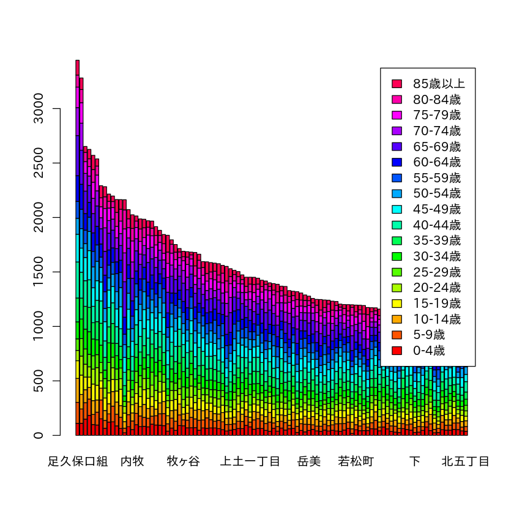

```r
#ソートしたものを表示する
barplot(t(des_data[1:100,5:22]), legend = labels,
        col = rainbow(18), names.arg = des_data[1:100,3])
```

#### 散布図を作成

各区の総数と70歳以上の人数のグラフを描く

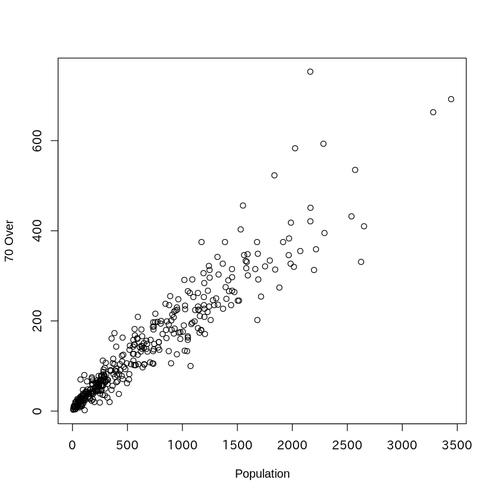

```r
#選択する年齢層のリストを作成
columnList <- c("総数", "X70.74歳","X75.79歳","X80.84歳","X85歳以上")
#葵区の総数と70歳以上の人数を選択
scatter <- csv_data[csv_data$区=="葵区",columnList,]
#70歳以上の人数の和を求める
scatter_y <- scatter[,2]+scatter[,3]+scatter[,4]+scatter[,5]
#プロット
plot(scatter[,1], scatter_y, xlab = "Population", ylab = "70 Over")
```

回帰直線を求める  
今回は、  
`scatter_y(70歳以上人口)` = 0.189785 * `scatter[,1](総数)` + 13.664494  
という回帰式が導出された

```r
#回帰直線を求める
result.lm <- lm(scatter_y ~ scatter[,1])
#回帰直線の内容を表示
summary(result.lm)
```

```
Call:
lm(formula = scatter_y ~ scatter[, 1])

Residuals:
    Min      1Q  Median      3Q     Max
-180.85  -16.23   -3.61   14.59  328.83

Coefficients:
              Estimate Std. Error t value Pr(>|t|)
(Intercept)  13.664494   3.152317   4.335 1.87e-05 ***
scatter[, 1]  0.189785   0.003444  55.112  < 2e-16 ***
---
Signif. codes:  0 ‘***’ 0.001 ‘**’ 0.01 ‘*’ 0.05 ‘.’ 0.1 ‘ ’ 1

Residual standard error: 41.95 on 380 degrees of freedom
Multiple R-squared:  0.8888,	Adjusted R-squared:  0.8885
F-statistic:  3037 on 1 and 380 DF,  p-value: < 2.2e-16
```

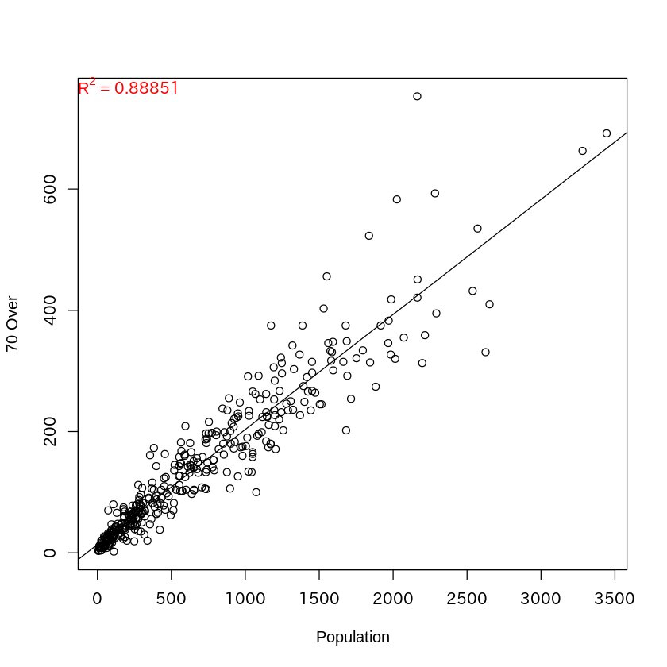

```r
#プロット
plot(scatter[,1], scatter_y, xlab = "Population", ylab = "70 Over")
#回帰直線を追加
abline(result.lm)
#R値を追加
mtext(substitute(paste(R^2," = ", text),
      list(text = round(summary(result.lm)$adj.r.squared,digits = 5))),
      line=-1,col=2,adj=0)
```